# 🚢 Titanic - Regresión Lineal

Erick Marroquín

2026-03-04

## 1. Planteamiento del Problema

Este ejercicio es **exclusivamente de REGRESIÓN LINEAL**.

Pregunta de investigación:

> ¿Qué variables explican el precio del boleto (Fare) pagado por los pasajeros del Titanic?

Variable respuesta (continua):

- **Fare**

Variables predictoras:

- Pclass (clase social)
- Sex (sexo)
- Age (edad)
- SibSp (hermanos/esposos a bordo)
- Parch (padres/hijos a bordo)
- Embarked (puerto de embarque)

Como la variable dependiente es continua, este es un problema clásico de regresión lineal múltiple.

## 2. Cargar librerías y datos

```r
library(tidyverse)
library(caret)
library(lmtest)
library(car)
```

```r
titanic <- read.csv("Titanic.csv")

str(titanic)
```

```
## 'data.frame':    891 obs. of  12 variables:
##  $ PassengerId: int  1 2 3 4 5 6 7 8 9 10 ...
##  $ Survived   : int  0 1 1 1 0 0 0 0 1 1 ...
##  $ Pclass     : int  3 1 3 1 3 3 1 3 3 2 ...
##  $ Name       : chr  "Braund, Mr. Owen Harris" "Cumings, Mrs. John Bradley (Florence Briggs Thayer)" "Heikkinen, Miss. Laina" "Futrelle, Mrs. Jacques Heath (Lily May Peel)" ...
##  $ Sex        : chr  "male" "female" "female" "female" ...
##  $ Age        : num  22 38 26 35 35 NA 54 2 27 14 ...
##  $ SibSp      : int  1 1 0 1 0 0 0 3 0 1 ...
##  $ Parch      : int  0 0 0 0 0 0 0 1 2 0 ...
##  $ Ticket     : chr  "A/5 21171" "PC 17599" "STON/O2. 3101282" "113803" ...
##  $ Fare       : num  7.25 71.28 7.92 53.1 8.05 ...
##  $ Cabin      : chr  "" "C85" "" "C123" ...
##  $ Embarked   : chr  "S" "C" "S" "S" ...
```

```r
summary(titanic)
```

```
##   PassengerId       Survived          Pclass          Name
##  Min.   :  1.0   Min.   :0.0000   Min.   :1.000   Length:891
##  1st Qu.:223.5   1st Qu.:0.0000   1st Qu.:2.000   Class :character
##  Median :446.0   Median :0.0000   Median :3.000   Mode  :character
##  Mean   :446.0   Mean   :0.3838   Mean   :2.309
##  3rd Qu.:668.5   3rd Qu.:1.0000   3rd Qu.:3.000
##  Max.   :891.0   Max.   :1.0000   Max.   :3.000
##
##      Sex                 Age            SibSp           Parch
##  Length:891         Min.   : 0.42   Min.   :0.000   Min.   :0.0000
##  Class :character   1st Qu.:20.12   1st Qu.:0.000   1st Qu.:0.0000
##  Mode  :character   Median :28.00   Median :0.000   Median :0.0000
##                     Mean   :29.70   Mean   :0.523   Mean   :0.3816
##                     3rd Qu.:38.00   3rd Qu.:1.000   3rd Qu.:0.0000
##                     Max.   :80.00   Max.   :8.000   Max.   :6.0000
##                     NA's   :177
##     Ticket               Fare           Cabin             Embarked
##  Length:891         Min.   :  0.00   Length:891         Length:891
##  Class :character   1st Qu.:  7.91   Class :character   Class :character
##  Mode  :character   Median : 14.45   Mode  :character   Mode  :character
##                     Mean   : 32.20
##                     3rd Qu.: 31.00
##                     Max.   :512.33
##
```

## 3. Preparación de datos

```r
data <- titanic %>%
  select(Fare, Pclass, Sex, Age, SibSp, Parch, Embarked) %>%
  na.omit()

data$Pclass <- as.factor(data$Pclass)
data$Sex <- as.factor(data$Sex)
data$Embarked <- as.factor(data$Embarked)
```

## 4. Análisis Exploratorio

### 4.1 Distribución de Fare

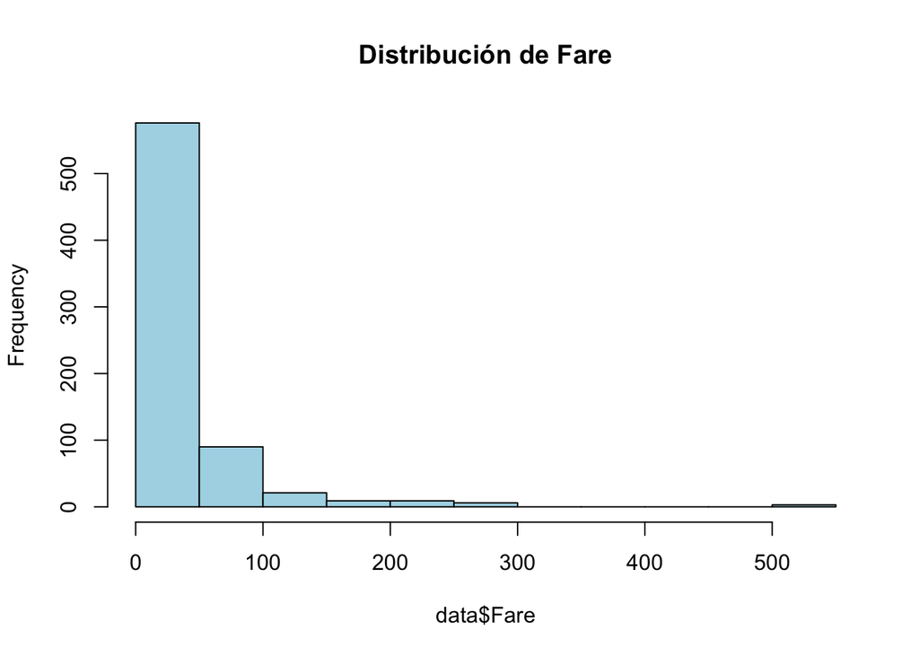

```r
hist(data$Fare, main="Distribución de Fare", col="lightblue")
```

Observamos asimetría positiva (valores altos extremos).

### 4.2 Fare según Clase

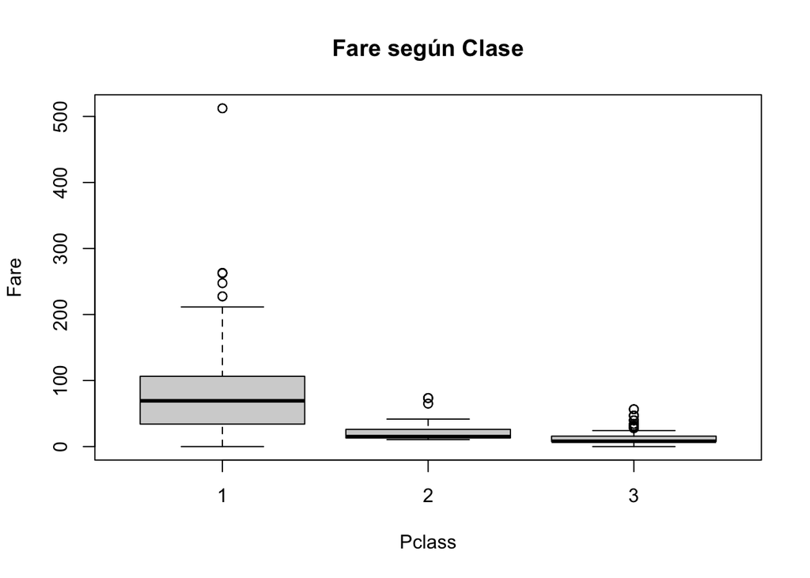

```r
boxplot(Fare ~ Pclass, data=data,
        main="Fare según Clase")
```

### 4.3 Fare según Sexo

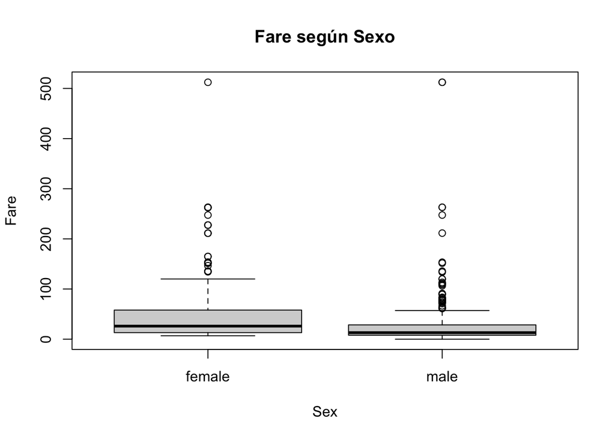

```r
boxplot(Fare ~ Sex, data=data,
        main="Fare según Sexo")
```

## 4.4 Relación Age vs Fare

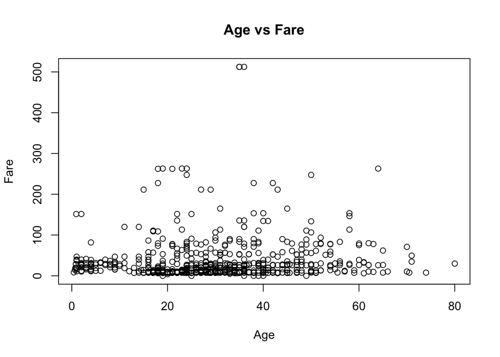

```r
plot(data$Age, data$Fare,
     xlab="Age", ylab="Fare",
     main="Age vs Fare")
```

Conclusión exploratoria:

- Fuerte efecto de Pclass.
- Posible influencia de Age.
- Presencia de valores atípicos en Fare.

## 5. Train/Test

```r
set.seed(314159654)

trainIndex <- createDataPartition(data$Fare, p = 0.7, list = FALSE)
train <- data[trainIndex, ]
test  <- data[-trainIndex, ]
```

70% entrenamiento, 30% prueba.

## 6. Construcción del Modelo de Regresión Lineal

```r
model <- lm(Fare ~ Pclass + Sex + Age + SibSp + Parch + Embarked,
            data = train)

summary(model)
```

```
##
## Call:
## lm(formula = Fare ~ Pclass + Sex + Age + SibSp + Parch + Embarked,
##     data = train)
##
## Residuals:
##    Min     1Q Median     3Q    Max
## -80.49 -15.29   0.00   7.73 415.90
##
## Coefficients:
##             Estimate Std. Error t value Pr(>|t|)
## (Intercept)  99.1272    42.1136   2.354   0.0190 *
## Pclass2     -62.9915     5.5623 -11.325  < 2e-16 ***
## Pclass3     -73.0258     5.2146 -14.004  < 2e-16 ***
## Sexmale      -7.6429     4.0644  -1.880   0.0606 .
## Age          -0.3085     0.1468  -2.101   0.0361 *
## SibSp         4.7558     2.1958   2.166   0.0308 *
## Parch        11.7838     2.5459   4.629 4.72e-06 ***
## EmbarkedC     8.0977    41.6105   0.195   0.8458
## EmbarkedQ    -7.6747    42.6108  -0.180   0.8571
## EmbarkedS   -10.0620    41.5426  -0.242   0.8087
## ---
## Signif. codes:  0 '***' 0.001 '**' 0.01 '*' 0.05 '.' 0.1 ' ' 1
##
## Residual standard error: 41.12 on 491 degrees of freedom
## Multiple R-squared:  0.4434, Adjusted R-squared:  0.4332
## F-statistic: 43.45 on 9 and 491 DF,  p-value: < 2.2e-16
```

Interpretación:

- Cada coeficiente representa el cambio esperado en Fare manteniendo las demás variables constantes.
- p-value < 0.05 indica significancia estadística.
- R² indica proporción de varianza explicada.

## 7. Verificación de Supuestos

### 7.1 Linealidad

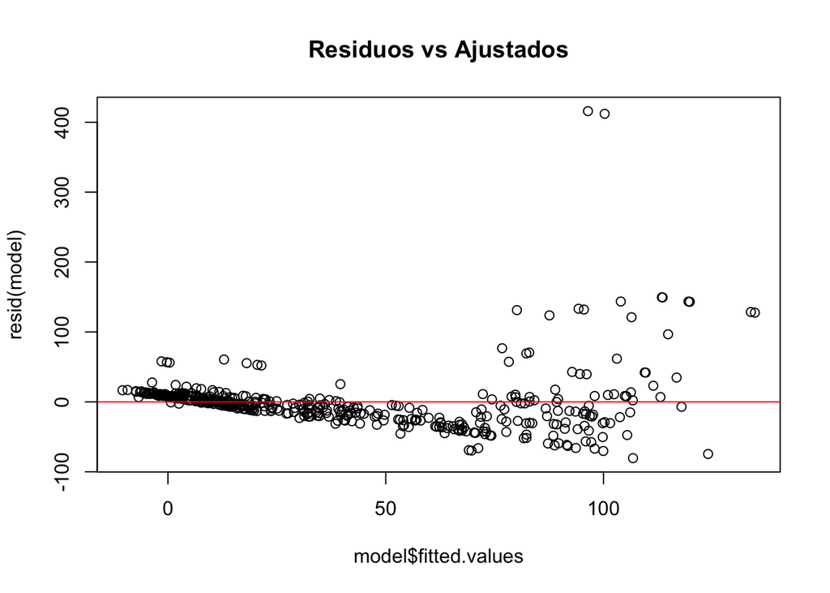

```r
plot(model$fitted.values, resid(model),
     main="Residuos vs Ajustados")
abline(h=0,col="red")
```

Buscamos ausencia de patrones sistemáticos.

### 7.2 Normalidad de residuos

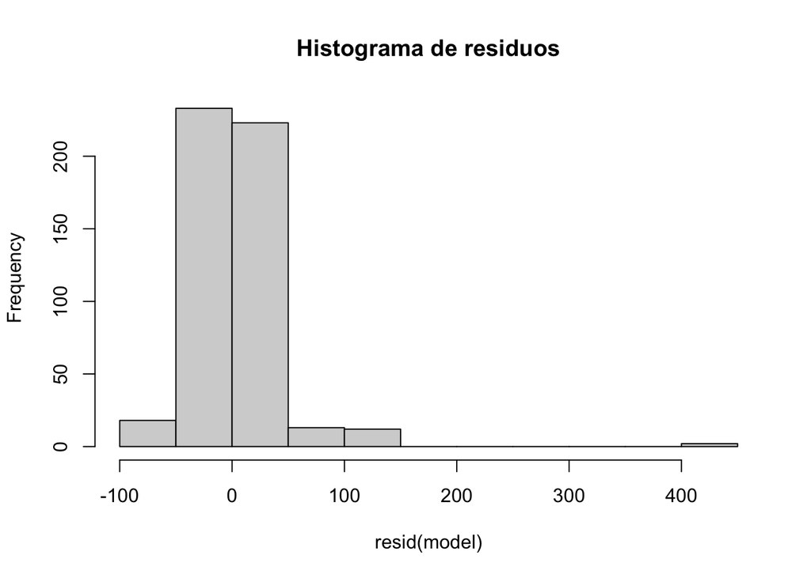

```r
hist(resid(model), main="Histograma de residuos")
```

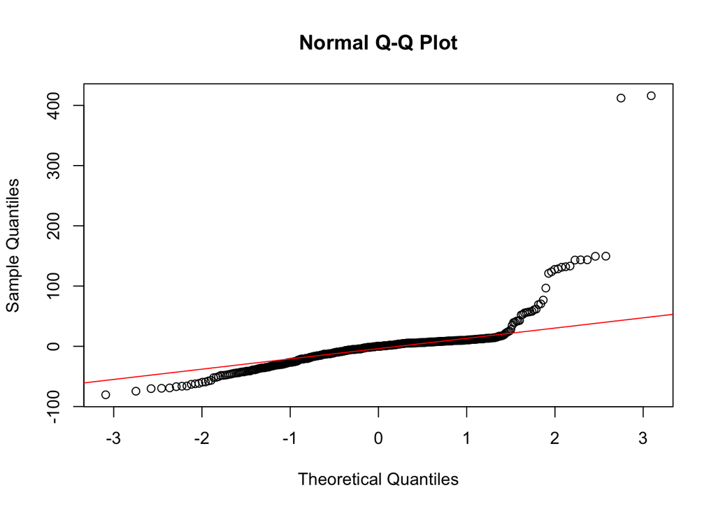

```r
qqnorm(resid(model))
qqline(resid(model), col="red")
```

```r
shapiro.test(resid(model))
```

```
##
##  Shapiro-Wilk normality test
##
## data:  resid(model)
## W = 0.62155, p-value < 2.2e-16
```

### 7.3 Homocedasticidad

```r
bptest(model)
```

```
##
##  studentized Breusch-Pagan test
##
## data:  model
## BP = 31.761, df = 9, p-value = 0.000219
```

### 7.4 Independencia

```r
dwtest(model)
```

```
##
##  Durbin-Watson test
##
## data:  model
## DW = 2.0358, p-value = 0.6556
## alternative hypothesis: true autocorrelation is greater than 0
```

### 7.5 Multicolinealidad

```r
vif(model)
```

```
##              GVIF Df GVIF^(1/(2*Df))
## Pclass   1.480098  2        1.102993
## Sex      1.129583  1        1.062818
## Age      1.398617  1        1.182632
## SibSp    1.342514  1        1.158669
## Parch    1.315503  1        1.146954
## Embarked 1.213181  3        1.032732
```

Valores VIF mayores a 5 indican posible colinealidad.

## 8. Validación del Modelo

```r
pred <- predict(model, test)

rmse <- RMSE(pred, test$Fare)
r2   <- summary(model)$r.squared

rmse
```

```
## [1] 37.87909
```

```r
r2
```

```
## [1] 0.4433672
```

Interpretación:

- RMSE mide el error promedio de predicción.
- R² indica qué tan bien el modelo explica la variabilidad de Fare.

## 9. Conclusión

Este ejercicio corresponde completamente a un problema de **regresión lineal múltiple**:

El modelo permite cuantificar cómo las características socioeconómicas influyen en el precio del boleto del Titanic.